# TIFF in the regions of England 2021

National statistics

# TIFF in the regions of England 2021

Updated 17 November 2022

© Crown copyright 2021

This publication is licensed under the terms of the Open Government Licence v3.0 except where otherwise stated. To view this licence, visit nationalarchives.gov.uk/doc/open-government-licence/version/3 or write to the Information Policy Team, The National Archives, Kew, London TW9 4DU, or email: psi@nationalarchives.gov.uk.

Where we have identified any third party copyright information you will need to obtain permission from the copyright holders concerned.

This publication is available at https://www.gov.uk/government/statistics/farm-business-income/farm-business-income-by-type-of-farm-england-202021

This publication contains the summary of the agricultural accounts in the regions of England for 2021 and will address trends for the ITL1 regions. This has been published alongside more detailed data sets for each of the respective ITL1 regions[^1], which further break down the data to ITL2 level. There are also summary datasets published at ITL3 level.

Total Income from Farming (TIFF) is the income to those who own businesses within the agricultural industry. It is the total profit from all UK farming businesses on a calendar year basis. It measures the return to all entrepreneurs for their management, inputs, labour and capital invested. The term ‘income’ used throughout this notice refers to TIFF.

#### User feedback

We want to improve our understanding of how people use our TIFF publications and how we can improve them to better meet user needs. Please take the time to complete a short feedback form to help us better understand user needs.

[User feedback form](https://docs.google.com/forms/d/1f0lVRIF5tqWKsqGCX_eyj7QqAyF0fo99YQUPbUwdFnU/edit)

## Section 1: Key messages

- TIFF in England in 2021 was £4,273 million, an increase of £636 million (17%) from 2020. In 2021 both crop and livestock output increased meaning that, although costs increased, TIFF also increased to be the second highest in real terms since 2000.
- TIFF increased in six of the eight regions and decreased in two. Where TIFF increased, the average increase was 24%, where it fell, the average decrease in TIFF was 4%.
- The East of England and the East Midlands contributed the most, of the ITL1 regions, to TIFF in England in 2021, contributing 20% and 18% respectively. The 2 ITL1 regions with the lowest contribution to TIFF in England in 2021 were the North East and the North West which together contributed 10%.

#### Figure 1.1: TIFF in the past 2 years in each ITL1 region of England (£ million)

| ITL1 region name | 2020 | 2021 |
| --- | --- | --- |
| East of England | 665 | 865 |
| East Midlands | 567 | 758 |
| South West | 663 | 660 |
| London and the South East | 486 | 592 |
| West Midlands | 446 | 511 |
| Yorkshire and The Humber | 397 | 461 |
| North West | 259 | 237 |
| North East | 154 | 190 |

- The highest TIFF in the regions in 2021 came from the East of England, which contributed £865 million an increase of £200 million (30%) from 2020. The East of England has consistently had the highest TIFF of the regions over the past 10 years except in 2017 and 2014 where it had the second highest.
- The lowest overall TIFF was from the North East, contributing £190 million. The North East has had the lowest TIFF of the regions every year for the last 10 years.
- The largest value change in TIFF in 2021 was also in the East of England, while the second largest change was in the East Midlands, where TIFF increased by £191 million (34%) to £758 million. This increase has moved it from being the third highest TIFF of the regions in 2020 to the second highest in 2021.

#### Figure 1.2: TIFF per hectare in the past 2 years in each ITL1 region of England (£/ha)

| ITL1 region name | 2020 | 2021 |
| --- | --- | --- |
| East Midlands | 471 | 630 |
| East of England | 476 | 619 |
| West Midlands | 479 | 548 |
| London and the South East | 427 | 520 |
| Yorkshire and The Humber | 356 | 413 |
| South West | 370 | 368 |
| North East | 254 | 314 |
| North West | 275 | 253 |

- The highest TIFF per hectare in England in 2021 was in the East Midlands, which had a TIFF per hectare of £630. This was an increase of £159 per hectare (34%) from 2020.
- The biggest mover between absolute TIFF and TIFF per hectare was the South West, which had the 3rd highest TIFF of any of the ITL1 regions of England but had only the 6th highest TIFF per hectare.

## Section 2: Outputs and subsidies

Below is a summary of the key points regarding outputs and subsidies at the ITL1 level. Any comparison made here between current and past years is made using current prices data as this is widely considered to be the most intuitive and helpful for year on year change.

### 2.1 Overview

#### Figure 2.1: Outputs and subsidies from each ITL1 region of England in 2021 split by percentage

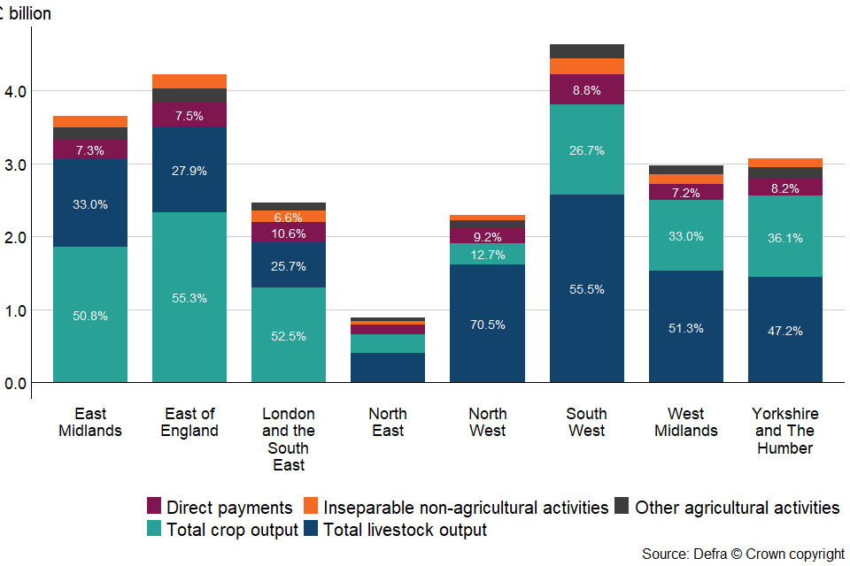

Figure 2.1 shows the breakdown of the outputs from the agricultural industry for each of the ITL1 regions by percentage between: crops, livestock, other agricultural activities and inseparable non-agricultural activities. Total livestock output was the largest output of 5 of the 8 ITL1 regions, with total crop output being the highest in the other 3. Direct payments made up between 7.2%, in the West Midlands, and 15.4%, in the North East, respectively, for the ITL1 regions.

Download ‘Total Income from Farming in the regions of England at ITL1’ (ODS, 90KB)

### 2.2 Crops

#### Figure 2.2: Top 3 ITL1 regions in England for crop output from 2016 - 2021 (£ million)

| Year | East Midlands | East of England | London and the South East |
| --- | --- | --- | --- |
| 2021 | 1,858 | 2,334 | 1,296 |
| 2020 | 1,398 | 1,877 | 1,097 |
| 2019 | 1,632 | 2,119 | 1,188 |
| 2018 | 1,557 | 1,872 | 1,136 |
| 2017 | 1,573 | 1,921 | 1,029 |
| 2016 | 1,415 | 1,714 | 944 |

- The East of England has had the largest total crop output value of any ITL1 region of England for the past 6 years. In 2021 it had a total crop output of £2,334 million, an increase of £457 million (24%) from 2020. 2020 was an abnormal year for crop yield so comparing to the more normal 2019, there was an increase of 10% to 2021.
- The East Midlands has, for the past 6 years, had the second highest crop output value of the ITL1 regions of England, with a crop output of £1,858 million in 2021.

Download ‘Total Income from Farming in the regions of England at ITL1’ (ODS, 90KB)

### 2.3 Livestock

#### Figure 2.3: Top 3 ITL1 regions in England for livestock output from 2016 - 2021 (£ million)

| Year | North West | West Midlands | South West |
| --- | --- | --- | --- |
| 2021 | 1,616 | 1,525 | 2,575 |
| 2020 | 1,477 | 1,393 | 2,445 |
| 2019 | 1,420 | 1,330 | 2,407 |
| 2018 | 1,371 | 1,272 | 2,388 |
| 2017 | 1,360 | 1,235 | 2,323 |
| 2016 | 1,188 | 1,105 | 2,009 |

- The South West has had the largest total livestock output value of any ITL1 region of England for the past 6 years. In 2021 it had a total livestock output of £2,575 million, an increase of £130 million (5%) from 2020.
- The North West has, for the past 6 years, had the second highest livestock output value of the ITL1 regions of England with a livestock output value of £1,616 million in 2021.

Download ‘Total Income from Farming in the regions of England at ITL1’ (ODS, 90KB)

### 2.4 Other outputs and subsidies<sup>(a)(b)</sup>

#### Figure 2.4: Other outputs and subsidies from each of the ITL1 regions of England in 2020 and 2021 (£ million)

| itl1_name | 2020 | 2021 |
| --- | --- | --- |
| South West | 826 | 827 |
| East of England | 691 | 711 |
| East Midlands | 570 | 594 |
| London and the South East | 534 | 537 |
| Yorkshire and The Humber | 505 | 515 |
| West Midlands | 454 | 468 |
| North West | 393 | 386 |
| North East | 230 | 226 |

<sup>(a)</sup>Since 2012, subsidies linked to production have only been paid in Scotland.

<sup>(b)</sup>Subsidies not linked to production are all subsidies not directly linked to production, including the basic payment scheme and agri-environment schemes.

## Section 3: Inputs and costs

### 3.1 Overview

#### Figure 3.1: Inputs and costs from each ITL1 region of England split by percentage in 2021

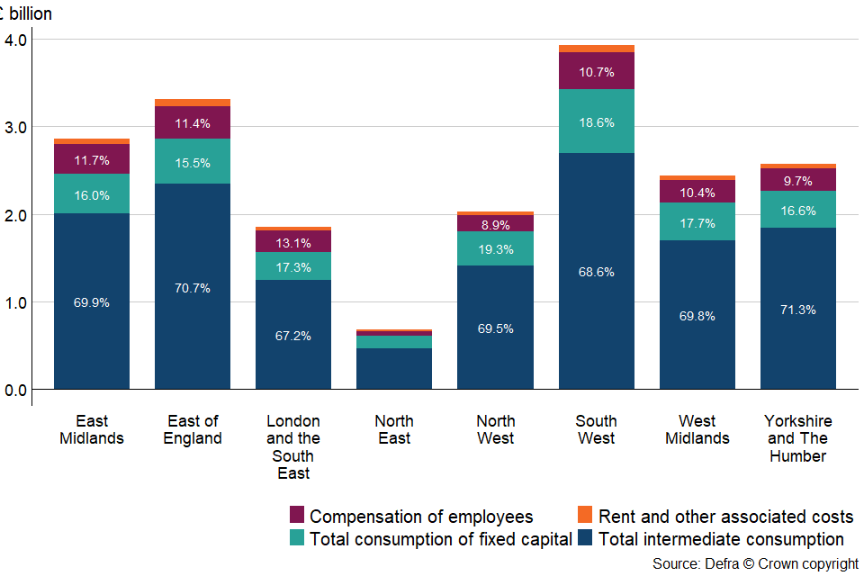

Figure 3.1 shows the breakdown of the costs from the agricultural industry in 2021 by percentage between: intermediate consumption, total fixed capital consumption, compensation of employees, rent and other costs. The order of costs from largest to smallest is the same across all of the ITL1 regions of England: intermediate consumption, total fixed capital consumption, compensation of employees, rent and other costs. Intermediate consumption made up between 67.2% and 71.3% of total costs and employment costs made up between 8.7%, in the North East, and 13.1%, in London and the south East in the ITL1 regions of England.

Download ‘Total Income from Farming in the regions of England at ITL1’ (ODS, 90KB)

Because the input costs of each region are dependant on what they produce, comparison of individual items between all ITL1 regions can be missleading. For this reason you will find a more detailed breakdown for each of the ITL1 regions linked below:

- TLC - The North East
- TLD - The North West
- TLE - Yorkshire and The Humber
- TLF - The East Midlands
- TLG - The West Midlands
- TLH - The East of England
- TLIJ - London and the South East
- TLK - The South West

## Section 4 - About these statistics

#### 4.1 Contact details

Tim Buttanshaw  
farmaccounts@defra.gov.uk  
Telephone: 020 8026 3601  
Media enquiries: 0345 051 8486  
Public enquiries: 0845 601 3034

Horizon House  
Deanery Road  
Bristol  
BS1 5AH

#### 4.2 Methodology

TIFF refers to income generated by production within the agricultural industry, including subsidies. TIFF represents business profits and remuneration for work done by owners and other unpaid workers. It excludes changes in the values of assets and stocks due to price changes, but includes non-agricultural activities such as further processing or tourist activities where these cannot be separated from the agricultural business. TIFF is the preferred measure of aggregate income for the agricultural industry, conforming to internationally agreed national accounting principles required by the UK National Accounts.

Values for the regions of England are derived by applying a factor to the England account for each of the regions, which is calculated using the June Survey data, to apportion the correct amount of the total England value to each region. Latest account information for England can be found at [England: Total Income from Farming statistics](https://www.gov.uk/government/statistics/total-income-from-farming-in-england).

The England level estimates used as a starting point for the estimates in this release were published by Defra on 01 July 2022.

#### 4.3 Revisions

- Due to the lack of availability of regional data for Direct payments, the methodology has been changed for this release to apportion them based on land area, which has been shown to correlate well with payments data. This means that Direct Payments data in this release is not directly comparable to that of previous releases.

Revisions are intended to increase the precision of the estimates and are routinely the result of more data becoming available over time. Sometimes additional revisions are necessary to refine the methodology or correct historical errors.

TIFF is the relatively small difference between two large numbers and is therefore sensitive to small percentage changes in the values of Outputs and Intermediate Consumption. A combination of a revision downwards in Output and revision upwards in Intermediate Consumption leads to more sizeable revisions in percentage terms to GVA and TIFF.

Further information can be found on the webpage for [Defra’s policy statement on revisions and correction](https://www.gov.uk/government/publications/defra-policy-statement-on-revisions-and-corrections/defra-policy-statement-on-revisions-and-corrections).

#### 4.4 Summary quality report

A summary quality report for this statistical release can be found on the GOV.UK website for Aggregate agricultural accounts. This is an overview note which is not release specific and was last updated in March 2019. It pulls together key qualitative information on the various dimensions of quality as well as providing a summary of methods used to compile the output. It relates to estimates of Total Income from Farming and aims to provide users with information on usability and fitness for purpose of these estimates.

#### 4.5 Quality assurance

DEFRA has in place quality assurance processes to check the accuracy and reliability of the aggregate agricultural accounts that include:

- Ongoing review of methods employed in the calculation of the accounts.
- Assessment of the quality of the estimates of the accounts with experts within DEFRA.
- Discussion of the accounts with external experts.

#### 4.6 Development areas

DEFRA statisticians carry out a continuous review of methods employed in making estimates of the production and income accounts. This may lead to revisions to data series owing to improvements in methods, in addition to the use of more up-to-date information.

#### 4.7 Main users and uses of these statistics

The aggregate agricultural accounts are used both within government and by the wider agricultural industry in conjunction with other economic information to:

- Monitor the productivity and competitiveness of the farming industry.
- Inform policy decisions and to help monitor and evaluate current policies relating to agriculture in the UK by Government.
- Inform stakeholders of the performance of the agricultural industry.
- Inform research into the economic performance of the agricultural industry.

#### 4.8 User engagement

As stated at the start of this release, part of our ongoing commitment to compliance with the Code of Practice for Official Statistics, is to strengthen our engagement with users of these statistics and better understand the use made of them as well as the types of decisions that they inform. Thus, we invite users to make themselves known, to advise us of the use they do, or might, make use of these statistics, and what their wishes are in terms of engagement. Feedback on this notice and inquiries about these statistics is also welcomed. Please complete [this feedback form](https://forms.gle/YRxFut32k5xVamW67) to tell us how you use this statistical notice.

#### 4.9 Future publications

These estimates for 2021 will be subject to minor (unless otherwise specified) revisions in future publications of TIFF in the regions of England where the availability of additional data and revised data will be incorporated to improve the accuracy of the estimates.

To find out the latest information on when UK government statistics will be released, go to the gov.uk Research and statistics webpage and select ‘Statistics (up-coming)’.

#### 4.10 Other publications relevant to this release

A number of publications released by DEFRA, are relevant to this release. Below is a list of the key publications and links to them on GOV.UK.

- [Total Income from Farming in the UK](https://www.gov.uk/government/statistics/total-income-from-farming-in-the-uk)
- [Total Income from Farming in England](https://www.gov.uk/government/statistics/total-income-from-farming-in-england)
- [Farm Business Survey: Farm Business Income](https://www.gov.uk/government/collections/farm-business-survey)